# DECIDIBILIDAD

Teoría de la Computación  
2026-2

Walter Quispe Vargas

wquispev@utec.edu.pe  
Departamento de Ciencia de la Computación, UTEC

# CONTENIDO

- OBJETIVOS
- DECIDIBILIDAD
  - Diseño de Máquinas de Turing Decidibles
  - Problemas de Lenguajes Regulares y Libres de Contexto.
- CONCLUSIONES

# OBJETIVOS

- Explorar la capacidad de los algoritmos (MT) para resolver problemas
- Diseñar Máquinas de Turing en alto nivel para problemas decidibles
  - Regulares
  - Libres de Contexto

## DECIDIBILIDAD

- LENGUAJES DECIDIBLES
  - Un lenguaje es decidible, si alguna M.T. toma la decisión de aceptar o rechazar una cadena (nunca entra en bucles).
  - Un algoritmo es un decididor.
- Formalizamos el **problema de pertenencia**.
- Nos enfocamos en lenguajes relacionados con lenguajes `regulares` y `libres de contexto`.
  - Antes: ¿El autómata B acepta la cadena $w$?
  - Ahora: $\scriptsize{A_{AFD}=\{ \langle B,w \rangle |B \mbox{ es un AFD que acepta la cadena } w\}}$
    - Donde $\langle B,w \rangle$ representa la **CODIFICACIÓN** de objeto autómata y la cadena $w$.

## DECIDIBILIDAD

- PROBLEMAS DECIDIBLES SOBRE LENGUAJES REGULARES
- TEOREMA: El lenguaje $A_{AFD}$ es decidible.
- $A_{AFD}=\{ \langle B,w \rangle |B \mbox{ es un AFD que acepta la cadena } w\}$
- Idea de la demostración:
  - Debemos diseñar una M.T. $M$ que decide el lenguaje $A_{AFD}$.
  - Esto es: Si $\langle B,w \rangle \in A_{AFD}$, $M$ **ACEPTA** o **RECHAZA** $\langle B,w \rangle$
  - Para esto, $M$ ordena a $B$ procesar $w$, esto se llama **SIMULAR** $B$ sobre $w$.
- Descripción de alto nivel:
- $M$ = “Para la cadena $\langle B,w \rangle$ donde $B$ es un A.F.D. y $w$ es una cadena:
  1. Simula $B$ procesando la cadena $w$.
  2. Si la simulación termina en un estado de aceptación, *ACEPTA*; si termina en un estado no final, *RECHAZA*.”

## DECIDIBILIDAD

- ¿Por qué es decidible?
  - Porque $B$ tiene un número finito de estados y $w$ tiene una longitud finita. La simulación avanzará exactamente $|w|$ pasos y se detendrá siempre.
- ¿Cómo es la Simulación?
  - Cuando $M$ lleva acabo la simulación, hace un seguimiento de los estados de $B$ con los simbolos de $w$, escribiendo la información en su cinta.
  - Inicialmente $B$ inicia en $q_0$, procesando el primer símbolo de $w$.
  - Los estados y la posición del símbolo de $w$ se actualizan mediante $\delta$
  - $M$ ACEPTA si $B$ esta en un estado de aceptación en el último simbolo de $w$.
  - $M$ RECHAZA si $B$ entra en un estado de no aceptación.

## DECIDIBILIDAD

- $A_{AFN} = \{\langle B, w \rangle \mid B \text{ es un AFN que acepta } w\}$
- TEOREMA: El lenguaje $A_{AFN}$ es decidible.
- Diseñamos una M.T. $N$ que decide $A_{AFN}$.
- Descripción de alto nivel:
- $N$ = “Para la cadena $\langle B,w \rangle \in A_{AFN}$:
  1. Convierte $B$ en su equivalente AFD $C$ usando el procedicimento visto en clase.
  2. Ejecunta $M$ del teorema anterior en la cadena $\langle C,w \rangle$
  3. Si $M$ acepta, *ACEPTA*; caso contrario, *RECHAZA*.”

## DECIDIBILIDAD

- $A_{REX} = \{\langle R, w \rangle \mid R \text{ es una Expresión Regular que genera } w\}$
- TEOREMA: El lenguaje $A_{REX}$ es decidible.
- Diseñamos una M.T. $P$ que decide $A_{REX}$.
- Descripción de alto nivel:
- $P$ = “Para la cadena $\langle R,w \rangle \in A_{REX}$:
  1. Convierte $R$ en su equivalente AFN $A$ usando el procedicimento visto en clase.
  2. Ejecunta $N$ del teorema anterior en la cadena $\langle A,w \rangle$
  3. Si $N$ acepta, *ACEPTA*; si $N$ rechaza, *RECHAZA*.”

## DECIDIBILIDAD

- EJERCICIOS:
- El problema del lenguaje vacío para AFD: $E_{AFD} = \{\langle A \rangle \mid A \text{ es un AFD y } L(A) = \emptyset\}$
  - El lenguaje $E_{AFD}$ es decidible
- El problema de equivalencia para AFD: $EQ_{AFD} = \{\langle A, B \rangle \mid A \text{ y } B \text{ son AFDs y } L(A) = L(B)\}$
  - El lenguaje $EQ_{AFD}$ es decidible

## DECIDIBILIDAD

- PROBLEMAS DECIDIBLES SOBRE LENGUAJES LIBRES DE CONTEXTO
- Sea el lenguaje $A_{GLC} = \{\langle G, w \rangle \mid G \text{ es una GLC que genera } w\}$
- TEOREMA: El lenguaje $A_{GLC}$ es decidible.
- Queremos determinar si $G$ genera $w$
- ¿Por qué no probamos todas las derivaciones posibles de $G$ hasta encontrar $w$?
- Si $G$ no genera $w$, la búsqueda exhaustiva podría durar eternamente (por ejemplo, con reglas como $A \to A$), lo que haría a la M.T. un reconocedor, pero no un decididor.
- Solución:
- Convertir la gramática $G$ a la Forma Normal de Chomsky (FNC).
- El problema $2.26$ (pag. 157) muestra que si $G$ está en FNC, cualquier derivación de $w$ tiene $2n-1$ pasos, donde $|w|=n$.
- Diseñamos una M.T. $S$ que decide $A_{GLC}$.
- Descripción de alto nivel:
- $S$ = “Para la cadena $\langle G,w \rangle \in A_{GLC}$:
  1. Convierte $G$ a una gramática equivalente $G'$ en Forma Normal de Chomsky.
  2. Enumera todas las derivaciones de longitud $2|w| - 1$ en $G'$, excepto si $w=\epsilon$, en cuyo caso la derivación es de un paso.
  3. Si alguna de las derivaciones produce $w$, *ACEPTA*; de lo contrario, *RECHAZA.*”

## DECIDIBILIDAD

- EJERCICIOS:
- El problema del lenguaje vacío para GLC: $E_{GLC} = \{\langle G \rangle \mid G \text{ es una GLC y } L(G) = \emptyset\}$
  - El lenguaje $E_{GLC}$ es decidible
- El problema de equivalencia para GLC: $EQ_{GLC} = \{\langle G, H \rangle \mid G \text{ y } H \text{ son GsLC y } L(G) = L(H)\}$
  - ¿El lenguaje $EQ_{GLC}$ es decidible?
  - 🚨 **NO**
  - Lenguajes Libres de Contexto **NO son cerrados bajo intersección ni complemento**.
- TEOREMA: Todo Lenguaje Libre de Contexto es Decidable
  - PRUEBA: Sea $L$ un LLC generado por la gramática $G$. Podemos construir un decididor $M_G$ que simplemente invoca al decididor de $A_{GLC}$ pasándole la codificación fija de la gramática $\langle G \rangle$ y la cadena de entrada $w$.

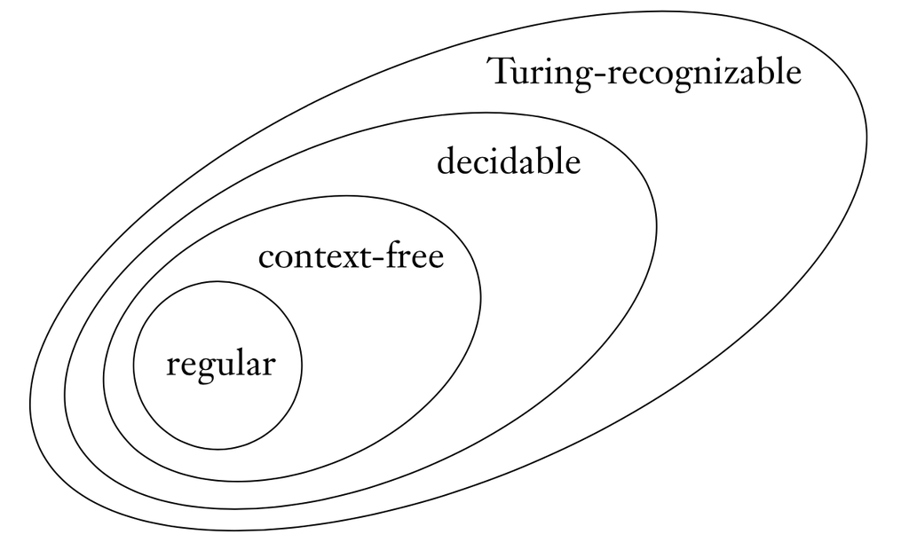

Tomado del libro: Introduction to Theory of Computer, Sipser

## DECIDIBILIDAD

- EJERCICIOS:
- $A_{\text{EVEN}} = \{\langle B \rangle \mid B \text{ es un AFD que acepta al menos una cadena de longitud par}\}$ Demuestre que $A_{\text{EVEN}}$ es decidible construyendo una Máquina de Turing de alto nivel que lo decida.
- $SUB_{\text{REX}} = \{\langle R, S \rangle \mid R \text{ y } S \text{ son expresiones regulares tales que } L(R) \subseteq L(S)\}$ Demuestre que es decidible.
- Sea el alfabeto $\Sigma = \{0, 1\}$. Considere el lenguaje: $L_{1^*} = \{\langle G \rangle \mid G \text{ es una GLC sobre } \Sigma \text{ tal que } L(G) \cap 1^* \neq \emptyset\}$, Demuestre que $L_{1^*}$ es decidible.
- Sea $PAL = \{w \in \{0,1\}^* \mid w = w^R\}$ el lenguaje de todos los palíndromos binarios. Considere el lenguaje: $PAL_{\text{AFD}} = \{\langle A \rangle \mid A \text{ es un AFD sobre } \{0,1\} \text{ tal que } L(A) \text{ contiene al menos un palíndromo}\}$, Demuestre que $PAL_{\text{AFD}}$ es decidible.
- Sea $L$ un lenguaje decidible sobre el alfabeto $\Sigma$. Se define el reverso del lenguaje como: $L^R = \{w^R \mid w \in L\}$, Demuestre que la clase de los lenguajes decidibles es cerrada bajo la operación de reverso; es decir, demuestre que si $L$ es decidible, entonces $L^R$ también es decidible.

## CONCLUSIONES

### En esta sesión aprendiste

- El concepto de decidibilidad
- Diseñar M.T. que deciden problemas de lenguajes regulares y libres de contexto.
- La Jerarquia de Lenguajes Formales.